# Paired Mass Distance(PMD) analysis for GC/LC-MS based non-targeted analysis

Miao Yu

2026-10-07

## Introduction of Paired Mass Distance analysis

`pmd` package use Paired Mass Distance (PMD) relationship to analysis the GC/LC-MS based non-targeted data. PMD means the distance between two masses or mass to charge ratios. In mass spectrometry, PMD would keep the same value between two masses and two mass to charge ratios(m/z). There are two kinds of PMD involved in this package: PMD from the same compound and PMD from different compounds. In GC/LC-MS or XCMS based non-targeted data analysis, peaks could be separated by chronograph and same compound means ions from similar retention times or ions co-eluted by certain column.

### PMD from the same compound

For MS1 full scan data, we could build retention time(RT) bins to assign peaks into different RT groups by retention time hierarchical clustering analysis. For each RT group, the peaks should come from same compounds or co-elutes. If certain PMD appeared in multiple RT groups, it would be related to the relationship about adducts, neutral loss, isotopologues or common fragments ions.

### PMD from different compounds

The peaks from different retention time groups would like to be different compounds separated by chronograph. The PMD would reflect the relationship about homologous series or chemical reactions.

GlobalStd algorithm use the PMD within same RT group to find independent peaks among certain data set. Then, structure/reaction directed analysis use PMD from different RT groups to screen important compounds or reactions.

## Data format

The input data should be a `list` object with at least two elements from a peaks list:

- mass to charge ratio with name of `mz`, high resolution mass spectrometry is required
- retention time with name of `rt`

However, I suggested to add intensity and group information to the list for validation of PMD analysis.

In this package, a data set from *in vivo* solid phase micro-extraction(SPME) was attached. This data set contain 9 samples from 3 fish with triplicates samples for each fish. Here is the data structure:

```r
library(pmd)
data("spmeinvivo")
str(spmeinvivo)
```

```
#> List of 4
#>  $ data : num [1:1459, 1:9] 1095 10439 10154 2797 90211 ...
#>   ..- attr(*, "dimnames")=List of 2
#>   .. ..$ : chr [1:1459] "100.1/170" "100.5/86" "101/85" "103.1/348" ...
#>   .. ..$ : chr [1:9] "1405_Fish1_F1" "1405_Fish1_F2" "1405_Fish1_F3" "1405_Fish2_F1" ...
#>  $ group:'data.frame':   9 obs. of  2 variables:
#>   ..$ sample_name : chr [1:9] "1405_Fish1_F1" "1405_Fish1_F2" "1405_Fish1_F3" "1405_Fish2_F1" ...
#>   ..$ sample_group: chr [1:9] "fish1" "fish1" "fish1" "fish2" ...
#>  $ mz   : num [1:1459] 100 101 101 103 104 ...
#>  $ rt   : num [1:1459] 170.2 86.3 84.9 348.1 48.8 ...
```

You could build this `list` or `mzrt` object from the `xcms` objects via `enviGCMS` package. When you have a `xcmsSet` object or `XCMSnExp` object named `xset`, you could use `enviGCMS::getmzrt(xset)` to get such list. Of course you could build such list by yourself.

## GlobalStd algorithm

GlobalStd algorithm try to find independent peaks among certain peaks list. The first step is retention time hierarchical clustering analysis. The second step is to find the relationship among adducts, neutral loss, isotopologues and common fragments ions. The third step is to screen the independent peaks.

Here is a workflow for this algorithm:

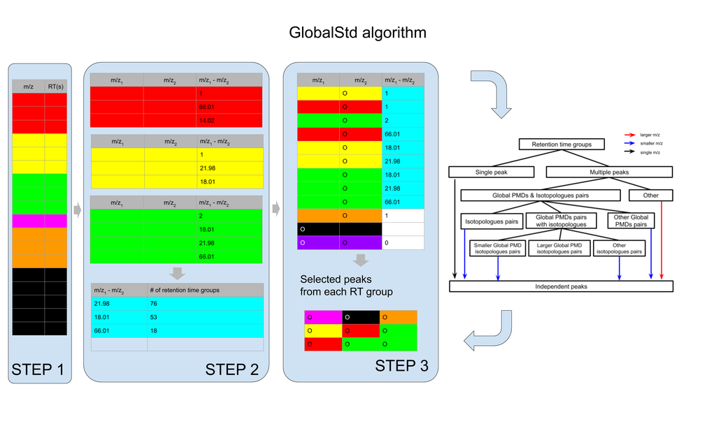

```r
knitr::include_graphics('https://yufree.github.io/presentation/figure/GlobalStd.png')
```

### STEP1: Retention time hierarchical clustering

```r
pmd <- getpaired(spmeinvivo)
```

```
#> 75 retention time clusters found.
#> Using ng = 15
#> 5 unique PMDs retained.
#> The unique within RT clusters high frequency PMD(s) is(are)  28.03 21.98 44.03 17.03 18.01.
#> 409 isotope peaks found.
#> 109 multiple charged isotope peaks found.
#> 4 multiple charged peaks found.
#> 346 paired peaks found.
```

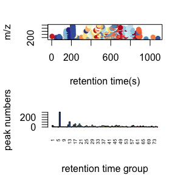

```r
plotrtg(pmd)
```

This plot would show the distribution of RT groups. The `rtcutoff` in function `getpaired` could be used to set the cutoff of the distances in retention time hierarchical clustering analysis. Retention time cluster cutoff should fit the peak picking algorithm. For HPLC, 10 is suggested and 5 could be used for UPLC.

Global PMD’s retention time group numbers should be around 20 percent of the retention time cluster numbers. For example, if you find 100 retention time clusters, I suggested you use 20 as the cutoff of empirical global PMD’s retention time group numbers. If you don’t specifically assign a value to `ng`, the algorithm will select such recommendation by default setting.

Take care of the retention time cluster with lots of peaks. In this case, such cluster could be co-eluted compounds on certain column. It would be wise to trim the retention time window for high quality peaks. Another important hint is that pre-filter your peak list by black samples or other quality control samples. Otherwise the running time would be long and lots of pmd relationship would be just from noise.

### STEP2: Relationship among adducts, neutral loss, isotopologues and common fragments ions

The `ng` in function `getpaired` could be used to set cutoff of global PMD’s retention time group numbers. If `ng` is 10, at least 10 of the retention time groups should contain the shown PMD relationship. You could use `plotpaired` to show the distribution.

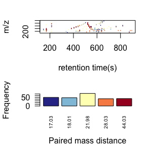

```r
plotpaired(pmd)
```

You could also show the distribution of PMD relationship by index:

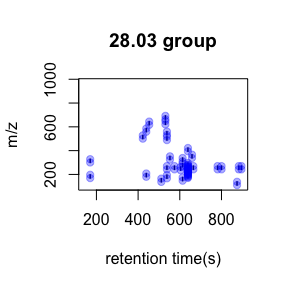

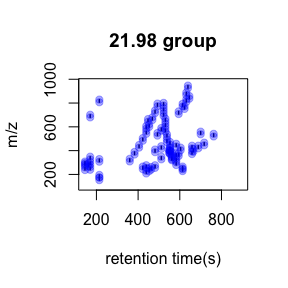

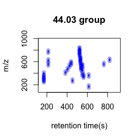

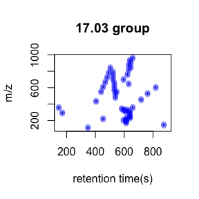

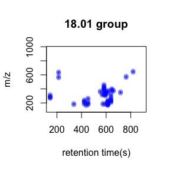

```r
# show the unique PMD found by getpaired function
for(i in 1:length(unique(round(pmd$paired$diff,2)))){
        diff <- unique(round(pmd$paired$diff,2))[i]
        index <- round(pmd$paired$diff,2)== diff
        plotpaired(pmd,index)
}
```

This is an easy way to find potential adducts of the data by high frequency PMD from the same compound. For example, 21.98 Da could be the mass distances between $[M+H]^+$ and $[M+Na]^+$. In this case, user could find the potential adducts or neutral loss even when they have no preferred adducts list. If one adduct exist in certain analytical system, the high frequency PMD will reveal such relationship. The high frequency PMD list could also be used to check the fragmental pattern of in-source reactions as long as such patterns are popular among all collected ions.

### STEP3: Screen the independent peaks

You could use `getstd` function to get the independent peaks. Independent peaks mean the peaks list removing the redundant peaks such as adducts, neutral loss, isotopologues and comment fragments ions found by PMD analysis in STEP2. Ideally, those peaks could be molecular ions while they might still contain redundant peaks.

```r
std <- getstd(pmd)
```

```
#> 8 group(s) have single peaks 14 23 32 33 54 55 56 75
#> 11 group(s) with multiple peaks while no isotope/paired relationship 4 5 7 8 11 ... 42 49 68 72 73
#> 9 group(s) with isotope without paired relationship 2 9 22 26 52 62 64 66 70
#> 4 group(s) with paired without isotope relationship 1 10 15 18
#> 43 group(s) with both paired and isotope relationship 3 6 12 13 16 ... 65 67 69 71 74
#> 291 standard masses identified.
```

Here you could plot the peaks by `plotstd` function to show the distribution of independent peaks:

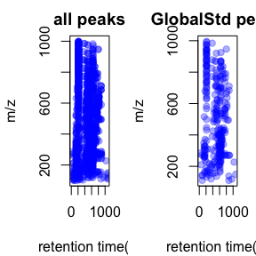

```r
plotstd(std)
```

You could also plot the peaks distribution by assign a retention time group via `plotstdrt`:

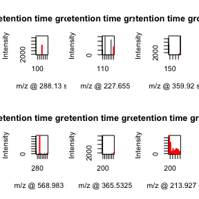

```r
par(mfrow = c(2,3))
plotstdrt(std,rtcluster = 23,main = 'Retention time group 23')
plotstdrt(std,rtcluster = 9,main = 'Retention time group 9')
plotstdrt(std,rtcluster = 18,main = 'Retention time group 18')
plotstdrt(std,rtcluster = 67,main = 'Retention time group 67')
plotstdrt(std,rtcluster = 49,main = 'Retention time group 49')
plotstdrt(std,rtcluster = 6,main = 'Retention time group 6')
```

### Extra filter with correlation coefficient cutoff

Original GlobalStd algorithm only use mass to charge ratio and retention time of peaks to select independent peaks. However, if intensity data across samples are available, correlation coefficient of paired ions could be used to further filter the random noise in high frequency PMDs. You could set up cutoff of Pearson Correlation Coefficient between peaks to refine the peaks selected by GlobalStd within same retention time groups. In this case, the numbers of selected independent peaks will be further reduced. When you use this parameter, make sure the intensity data are from real samples instead of blank samples, which will affect the calculation of correlation coefficient.

```r
std2 <- globalstd(pmd,corcutoff = 0.9)
```

```
#> 75 retention time clusters found.
#> Using ng = 15
#> 2 unique PMDs retained.
#> The unique within RT clusters high frequency PMD(s) is(are)  21.98 17.03.
#> 242 isotope peaks found.
#> 63 multiple charged isotope peaks found.
#> 3 multiple charged peaks found.
#> 120 paired peaks found.
#> 8 group(s) have single peaks 14 23 32 33 54 55 56 75
#> 23 group(s) with multiple peaks while no isotope/paired relationship 2 4 5 7 8 ... 68 69 70 72 73
#> 17 group(s) with isotope without paired relationship 9 12 20 22 24 ... 60 64 66 67 71
#> 3 group(s) with paired without isotope relationship 1 53 74
#> 24 group(s) with both paired and isotope relationship 3 6 13 16 17 ... 48 58 61 63 65
#> 206 standard masses identified.
```

## Validation by principal components analysis(PCA)

You need to check the GlobalStd algorithm’s results by principal components analysis(PCA). If we removed too much peaks containing information, the score plot of reduced data set would show great changes.

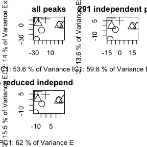

```r
library(enviGCMS)
par(mfrow = c(2,2),mar = c(4,4,2,1)+0.1)
plotpca(std$data,lv = as.numeric(as.factor(std$group$sample_group)),main = "all peaks")
plotpca(std$data[std$stdmassindex,],lv = as.numeric(as.factor(std$group$sample_group)),main = paste(sum(std$stdmassindex),"independent peaks"))
plotpca(std2$data[std2$stdmassindex,],lv = as.numeric(as.factor(std$group$sample_group)),main = paste(sum(std2$stdmassindex),"reduced independent peaks"))
```

You might find original GlobalStd algorithm show a similar PCA score plot with original data while GlobalStd algorithm considering intensity data seems change the profile. The major reason is that correlation coefficient option in the algorithm will remove the paired ions without strong correlation. It will be aggressive to remove low intensity peaks, which are vulnerable by baseline noise. However, such options would be helpful if you only concern high quality peaks for following analysis. Otherwise, original GlobalStd will keep the most information for discover purpose.

## Comparison with other pseudo spectra extraction method

GlobalStd algorithm in `pmd` package could be treated as a method to extract pseudo spectra. You could use `getpseudospectrum` to get peaks groups information for all GlobalStd peaks. This function would consider the merge of GlobalStd peaks when certain peak is involved in multiple clusters. Then you could choose export peaks with the highest intensities or base peaks in each GlobalStd merged peaks groups. Meanwhile, you could also include the correlation coefficient cutoff to further improve the data quality.

```r
stdcluster <- getpseudospectrum(std)
```

```
#> 75 retention time clusters found.
#> Using ng = 15
#> 5 unique PMDs retained.
#> The unique within RT clusters high frequency PMD(s) is(are)  28.03 21.98 44.03 17.03 18.01.
#> 409 isotope peaks found.
#> 109 multiple charged isotope peaks found.
#> 4 multiple charged peaks found.
#> 346 paired peaks found.
#> 245 pseudo spectrum found.
#> 0.84 peaks covered by PMD relationship.
```

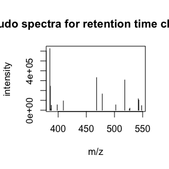

```r
# extract the first pseudospectra for retention time cluster 37
idx <- stdcluster$pseudo$sid=='37@1'
plot(stdcluster$pseudo$mz[idx],stdcluster$pseudo$ins[idx],type = 'h',xlab = 'm/z',ylab = 'intensity',main = 'pseudo spectra for retention time cluster 37')
```

```r
# considering the correlation coefficient cutoff
stdcluster2 <- getpseudospectrum(std, corcutoff = 0.9)
```

```
#> 75 retention time clusters found.
#> Using ng = 15
#> 2 unique PMDs retained.
#> The unique within RT clusters high frequency PMD(s) is(are)  21.98 17.03.
#> 242 isotope peaks found.
#> 63 multiple charged isotope peaks found.
#> 3 multiple charged peaks found.
#> 120 paired peaks found.
#> 80 pseudo spectrum found.
#> 0.97 peaks covered by PMD relationship.
```

We supplied `getcorpseudospectrum` to find peaks groups by correlation analysis only. The base peaks of correlation cluster were selected to stand for the compounds.

```r
corcluster <- getcorpseudospectrum(spmeinvivo)
```

```
#> 75 retention time cluster found.
#> 141 pseudo spectrum found.
#> 0.72 peaks covered by PMD relationship.
```

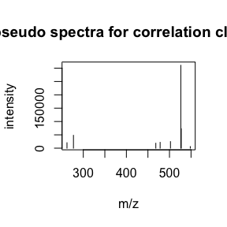

```r
# extract pseudospectra 37@1
peak <- corcluster$pseudo[corcluster$pseudo$sid == '37@1',]
plot(peak$ins~peak$mz,type = 'h',xlab = 'm/z',ylab = 'intensity',main = 'pseudo spectra for correlation cluster')
```

Then we could compare the reduced result using multiple similarity factors. A good peak selection algorithm should maintain the structural consistency (e.g. Normalized Spectral Entropy, RV Coefficient, and Mantel test). We supplied `getsim` function to output PCASF, RV, Mantel correlation, and Spectral Entropy ratio between the original and reduced datasets.

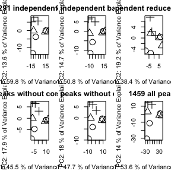

```r
par(mfrow = c(2,3),mar = c(4,4,2,1)+0.1)
plotpca(std$data[std$stdmassindex,],lv = as.numeric(as.factor(std$group$sample_group)),main = paste(sum(std$stdmassindex),"independent peaks"))
plotpca(std$data[stdcluster$stdmassindex2,],lv = as.numeric(as.factor(std$group$sample_group)),main = paste(sum(stdcluster$stdmassindex2),"independent base peaks"))
plotpca(std$data[stdcluster2$stdmassindex2,],lv = as.numeric(as.factor(std$group$sample_group)),main = paste(sum(stdcluster2$stdmassindex2),"independent reduced base peaks"))
plotpca(std$data[corcluster$stdmassindex,],lv = as.numeric(as.factor(std$group$sample_group)),main = paste(sum(corcluster$stdmassindex),"peaks without correlationship"))
plotpca(std$data[corcluster$stdmassindex2,],lv = as.numeric(as.factor(std$group$sample_group)),main = paste(sum(corcluster$stdmassindex2),"base peaks without correlationship"))
plotpca(std$data,lv = as.numeric(as.factor(std$group$sample_group)),main = paste(nrow(std$data),"all peaks"))
```

```r
# Evaluate multiple algorithms against original data
getsim(std$data, std$data[std$stdmassindex,])
```

```
#>              PCASF                 RV     Mantel_Pearson    Mantel_Spearman
#>                 NA          0.9744418          0.9680196          0.9554698
#> Spectral_Entropy_x Spectral_Entropy_y      Entropy_Ratio              NSE_x
#>          0.8000474          0.6874659          0.8592815          0.3641172
#>              NSE_y
#>          0.3128792
```

```r
getsim(std$data, std$data[stdcluster$stdmassindex2,])
```

```
#>              PCASF                 RV     Mantel_Pearson    Mantel_Spearman
#>                 NA          0.8599917          0.8371042          0.8404118
#> Spectral_Entropy_x Spectral_Entropy_y      Entropy_Ratio              NSE_x
#>          0.8000474          0.7130890          0.8913086          0.3641172
#>              NSE_y
#>          0.3245408
```

```r
getsim(std$data, std$data[corcluster$stdmassindex2,])
```

```
#>              PCASF                 RV     Mantel_Pearson    Mantel_Spearman
#>                 NA          0.7673804          0.7300709          0.7122265
#> Spectral_Entropy_x Spectral_Entropy_y      Entropy_Ratio              NSE_x
#>          0.8000474          0.4959912          0.6199523          0.3641172
#>              NSE_y
#>          0.2257353
```

### Benchmark different datasets by Normalized Spectral Entropy (Sample Consistency Metric)

If you need to evaluate the internal dimensionality and information purity of non-aligned peak tables (e.g., outputs spanning different platforms or algorithms without same variables), use `getnse()` to measure the Normalized Spectral Entropy.

```r
# Calculate SCM/NSE for the full data and the reduced standard masses
getnse(std$data)
```

```
#> [1] 0.3641172
```

```r
getnse(std$data[std$stdmassindex,])
```

```
#> [1] 0.3128792
```

## Structure/Reaction directed analysis

`getsda` function could be used to perform Structure/reaction directed analysis. The cutoff of frequency is automate found by PMD network analysis with the largest mean distance of all nodes.

```r
sda <- getsda(std)
```

```
#> PMD frequency cutoff is 6 by PMD network analysis with largest network average distance 6.67 .
#> 53 groups were found as high frequency PMD group.
#> 0 was found as high frequency PMD.
#> 1.98 was found as high frequency PMD.
#> 2.01 was found as high frequency PMD.
#> 2.02 was found as high frequency PMD.
#> 6.97 was found as high frequency PMD.
#> 11.96 was found as high frequency PMD.
#> 12 was found as high frequency PMD.
#> 13.98 was found as high frequency PMD.
#> 14.02 was found as high frequency PMD.
#> 14.05 was found as high frequency PMD.
#> 15.99 was found as high frequency PMD.
#> 16.03 was found as high frequency PMD.
#> 19.04 was found as high frequency PMD.
#> 28.03 was found as high frequency PMD.
#> 30.05 was found as high frequency PMD.
#> 31.99 was found as high frequency PMD.
#> 33.02 was found as high frequency PMD.
#> 37.02 was found as high frequency PMD.
#> 42.05 was found as high frequency PMD.
#> 48.04 was found as high frequency PMD.
#> 48.98 was found as high frequency PMD.
#> 49.02 was found as high frequency PMD.
#> 54.05 was found as high frequency PMD.
#> 56.06 was found as high frequency PMD.
#> 56.1 was found as high frequency PMD.
#> 58.04 was found as high frequency PMD.
#> 58.08 was found as high frequency PMD.
#> 58.11 was found as high frequency PMD.
#> 63.96 was found as high frequency PMD.
#> 66.05 was found as high frequency PMD.
#> 68.06 was found as high frequency PMD.
#> 70.04 was found as high frequency PMD.
#> 70.08 was found as high frequency PMD.
#> 74.02 was found as high frequency PMD.
#> 80.03 was found as high frequency PMD.
#> 82.08 was found as high frequency PMD.
#> 88.05 was found as high frequency PMD.
#> 91.1 was found as high frequency PMD.
#> 93.12 was found as high frequency PMD.
#> 94.1 was found as high frequency PMD.
#> 96.09 was found as high frequency PMD.
#> 101.05 was found as high frequency PMD.
#> 108.13 was found as high frequency PMD.
#> 110.11 was found as high frequency PMD.
#> 112.16 was found as high frequency PMD.
#> 116.08 was found as high frequency PMD.
#> 122.15 was found as high frequency PMD.
#> 124.16 was found as high frequency PMD.
#> 126.14 was found as high frequency PMD.
#> 144.18 was found as high frequency PMD.
#> 148.04 was found as high frequency PMD.
#> 150.2 was found as high frequency PMD.
#> 173.18 was found as high frequency PMD.
```

Such largest mean distance of all nodes is calculated for top 1 to 100 (if possible) high frequency PMDs. Here is a demo for the network generation process.

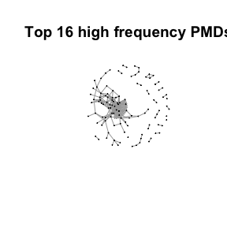

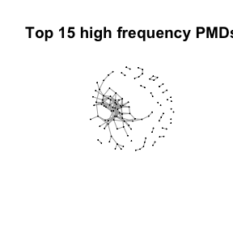

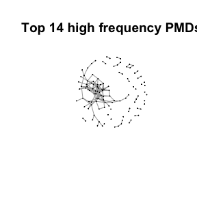

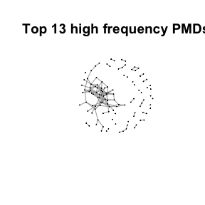

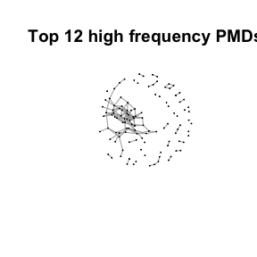

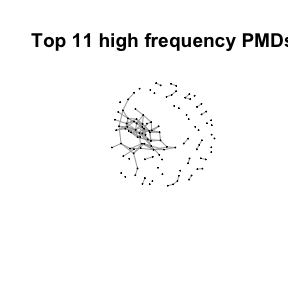

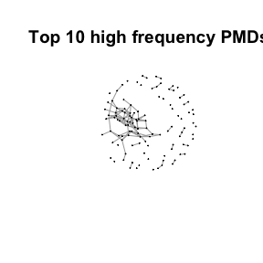

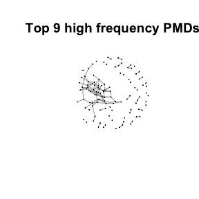

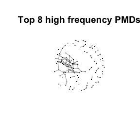

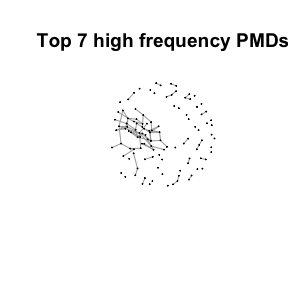

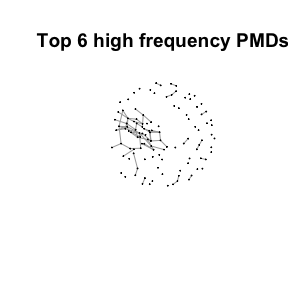

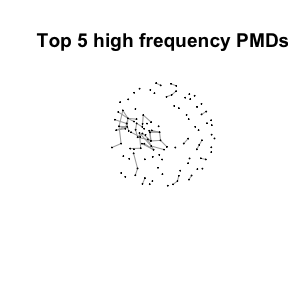

[5 more figures not shown]

```r
library(igraph)
cdf <- sda$sda
# get the PMDs and frequency
pmds <- as.numeric(names(sort(table(cdf$diff2),decreasing = T)))
freq <- sort(table(cdf$diff2),decreasing = T)
# filter the frequency larger than 10 for demo
pmds <- pmds[freq>10]
cdf <- sda$sda[sda$sda$diff2 %in% pmds,]
g <- igraph::graph_from_data_frame(cdf,directed = F)
l <- igraph::layout_with_fr(g)
for(i in 1:length(pmds)){
  g2 <- igraph::delete_edges(g,which(E(g)$diff2%in%pmds[1:i]))
  plot(g2,edge.width=1,vertex.label="",vertex.size=1,layout=l,main=paste('Top',length(pmds)-i,'high frequency PMDs'))
}
```

Here we could find more and more compounds will be connected with more high frequency PMDs. Meanwhile, the mean distance of all network nodes will increase. However, some PMDs are generated by random combination of ions. In this case, if we included those PMDs for the network, the mean distance of all network nodes will decrease. Here, the largest mean distance means no more information will be found for certain data set and such value is used as the cutoff for high frequency PMDs selection.

You could use `plotstdsda` to show the distribution of the selected paired peaks.

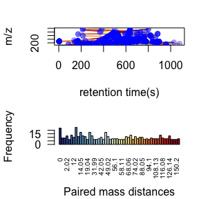

```r
plotstdsda(sda)
```

You could also use index to show the distribution of certain PMDs.

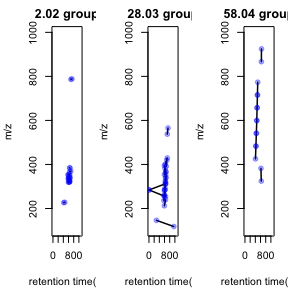

```r
par(mfrow = c(1,3),mar = c(4,4,2,1)+0.1)
plotstdsda(sda,sda$sda$diff2 == 2.02)
plotstdsda(sda,sda$sda$diff2 == 28.03)
plotstdsda(sda,sda$sda$diff2 == 58.04)
```

Structure/reaction directed analysis could be directly performed on all the peaks, which is slow to process:

```r
sdaall <- getsda(spmeinvivo)
```

```
#> PMD frequency cutoff is 104 by PMD network analysis with largest network average distance 14.06 .
#> 6 groups were found as high frequency PMD group.
#> 0 was found as high frequency PMD.
#> 2.02 was found as high frequency PMD.
#> 28.03 was found as high frequency PMD.
#> 31.01 was found as high frequency PMD.
#> 58.04 was found as high frequency PMD.
#> 116.08 was found as high frequency PMD.
```

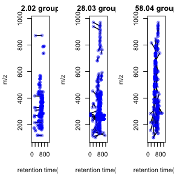

```r
par(mfrow = c(1,3),mar = c(4,4,2,1)+0.1)
plotstdsda(sdaall,sdaall$sda$diff2 == 2.02)
plotstdsda(sdaall,sdaall$sda$diff2 == 28.03)
plotstdsda(sdaall,sdaall$sda$diff2 == 58.04)
```

### Extra filter with correlation coefficient cutoff

Structure/Reaction directed analysis could also use correlation to restrict the paired ions. However, similar to GlobalStd algorithm, such cutoff will remove low intensity data. Researcher should have a clear idea to use this cutoff.

```r
sda2 <- getsda(std, corcutoff = 0.9)
```

```
#> PMD frequency cutoff is 6 by PMD network analysis with largest network average distance 6.67 .
#> 41 groups were found as high frequency PMD group.
#> 0 was found as high frequency PMD.
#> 1.98 was found as high frequency PMD.
#> 2.01 was found as high frequency PMD.
#> 2.02 was found as high frequency PMD.
#> 11.96 was found as high frequency PMD.
#> 12 was found as high frequency PMD.
#> 13.98 was found as high frequency PMD.
#> 14.02 was found as high frequency PMD.
#> 14.05 was found as high frequency PMD.
#> 15.99 was found as high frequency PMD.
#> 16.03 was found as high frequency PMD.
#> 19.04 was found as high frequency PMD.
#> 28.03 was found as high frequency PMD.
#> 30.05 was found as high frequency PMD.
#> 31.99 was found as high frequency PMD.
#> 33.02 was found as high frequency PMD.
#> 42.05 was found as high frequency PMD.
#> 48.98 was found as high frequency PMD.
#> 49.02 was found as high frequency PMD.
#> 54.05 was found as high frequency PMD.
#> 56.06 was found as high frequency PMD.
#> 58.04 was found as high frequency PMD.
#> 58.08 was found as high frequency PMD.
#> 63.96 was found as high frequency PMD.
#> 66.05 was found as high frequency PMD.
#> 68.06 was found as high frequency PMD.
#> 70.08 was found as high frequency PMD.
#> 74.02 was found as high frequency PMD.
#> 80.03 was found as high frequency PMD.
#> 82.08 was found as high frequency PMD.
#> 88.05 was found as high frequency PMD.
#> 93.12 was found as high frequency PMD.
#> 94.1 was found as high frequency PMD.
#> 96.09 was found as high frequency PMD.
#> 108.13 was found as high frequency PMD.
#> 110.11 was found as high frequency PMD.
#> 112.16 was found as high frequency PMD.
#> 116.08 was found as high frequency PMD.
#> 122.15 was found as high frequency PMD.
#> 124.16 was found as high frequency PMD.
#> 126.14 was found as high frequency PMD.
```

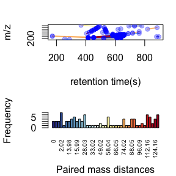

```r
plotstdsda(sda2)
```

### Structure/reaction directed analysis for peaks/compounds only data

When you only have data of peaks without retention time or compounds list, structure/reaction directed analysis could also be done by `getrda` function.

```r
sda <- getrda(spmeinvivo$mz)
```

```
#> 164462 pmd found.
#> 20 pmd used.
```

```r
# check high frequency pmd
colnames(sda)
```

```
#>  [1] "0"       "1.001"   "1.002"   "1.003"   "1.004"   "2.015"   "2.016"
#>  [8] "14.015"  "17.026"  "18.011"  "21.982"  "28.031"  "28.032"  "44.026"
#> [15] "67.987"  "67.988"  "88.052"  "116.192" "135.974" "135.975"
```

```r
# get certain pmd related m/z
idx <- sda[,'2.016']
# show the m/z
spmeinvivo$mz[idx]
```

```
#>  [1] 118.0651 118.0652 120.0812 159.1575 162.0552 170.0330 170.0932 170.1541
#>  [9] 174.1363 174.9917 175.0873 176.0305 176.0418 181.9872 184.1695 188.6484
#> [17] 192.1487 192.1604 226.9522 226.9523 228.1969 228.1973 259.1148 261.1317
#> [25] 270.3185 271.3217 272.3230 272.3234 273.8902 274.8744 284.2955 285.3002
#> [33] 285.3002 286.3101 286.3101 291.0712 293.1755 294.9392 296.2961 304.3081
#> [41] 305.2480 305.3118 308.0889 308.2953 308.2954 309.1672 309.2046 315.1781
#> [49] 317.9344 319.3005 319.3002 319.9302 320.3041 320.3322 321.3165 322.3185
#> [57] 323.3221 324.3266 325.3294 327.2022 327.3449 329.0052 331.0031 350.3426
#> [65] 352.3214 352.3215 353.3244 354.3365 355.0696 359.2410 361.2353 372.3197
#> [73] 375.3066 383.2804 383.3723 384.3350 385.2753 385.3480 387.2851 397.1907
#> [81] 399.3274 400.9174 401.3420 403.2859 432.8860 433.2781 445.8289 447.1173
#> [89] 451.3633 462.8615 522.3557 524.1178 525.9831 526.4841 705.7223 708.8218
#> [97] 976.3139 976.8122 982.7763
```

## Wrap function for GlobalStd algorithm

`globalstd` function is a wrap function to process GlobalStd algorithm and structure/reaction directed analysis in one line. All the plot function could be directly used on the `list` objects from `globalstd` function. If you want to perform structure/reaction directed analysis, set the `sda=T` in the `globalstd` function.

```r
result <- globalstd(spmeinvivo, sda=FALSE)
```

```
#> 75 retention time clusters found.
#> Using ng = 15
#> 5 unique PMDs retained.
#> The unique within RT clusters high frequency PMD(s) is(are)  28.03 21.98 44.03 17.03 18.01.
#> 409 isotope peaks found.
#> 109 multiple charged isotope peaks found.
#> 4 multiple charged peaks found.
#> 346 paired peaks found.
#> 8 group(s) have single peaks 14 23 32 33 54 55 56 75
#> 11 group(s) with multiple peaks while no isotope/paired relationship 4 5 7 8 11 ... 42 49 68 72 73
#> 9 group(s) with isotope without paired relationship 2 9 22 26 52 62 64 66 70
#> 4 group(s) with paired without isotope relationship 1 10 15 18
#> 43 group(s) with both paired and isotope relationship 3 6 12 13 16 ... 65 67 69 71 74
#> 291 standard masses identified.
```

## Use independent peaks for MS/MS validation (PMDDA)

Independent peaks are supposing generated from different compounds. We could use those peaks for MS/MS analysis instead of DIA or DDA. Here we need multiple injections for one sample since it might be impossible to get all ions’ fragment ions in one injection with good sensitivity. You could use `gettarget` to generate the index for the injections and output the peaks for each run.

```r
# you need retention time for independent peaks
index <- gettarget(std$rt[std$stdmassindex])
```

```
#> You need 10 injections!
```

```r
# output the ions for each injection
table(index)
```

```
#> index
#>  1  2  3  4  5  6  7  8  9 10
#> 28 21 38 19 20 26 46 37 32 24
```

```r
# show the ions for the first injection
std$mz[index==1]
```

```
#>   [1] 104.0090 110.0092 125.9874 140.0600 153.1277 155.1294 155.1294 158.1546
#>   [9] 167.0901 175.0873 175.1482 183.0809 195.1024 228.1973 229.6753 233.2268
#>  [17] 236.9406 239.1628 241.2366 242.2863 242.2863 242.9260 244.0288 251.1650
#>  [25] 255.1591 255.2077 255.9443 259.1148 262.1656 263.2015 270.3172 271.3217
#>  [33] 274.9319 277.1817 279.1610 282.0531 286.3101 299.1113 300.2046 306.2514
#>  [41] 311.2377 337.3298 338.3435 339.6388 341.0180 341.3615 342.3637 344.3500
#>  [49] 345.9293 351.3455 352.3214 357.3157 362.3032 362.9280 364.3575 366.3006
#>  [57] 368.3904 370.3567 382.3673 389.2529 395.3642 399.2514 400.2536 403.2859
#>  [65] 413.2687 421.2521 424.0815 430.0895 439.2698 485.2901 492.8839 494.8112
#>  [73] 494.8114 499.9050 500.9073 501.2808 501.3829 507.3303 507.3409 520.2968
#>  [81] 526.4841 527.1586 528.4989 534.9708 538.5405 539.5420 551.3562 562.1811
#>  [89] 567.5729 569.3449 570.3554 578.1272 593.5980 607.4028 608.4285 620.4358
#>  [97] 638.2008 680.4633 684.2033 686.2013 692.4941 695.6533 697.8511 698.7711
#> [105] 699.8553 704.1390 704.6384 710.8511 719.2988 719.9400 723.4865 731.7391
#> [113] 737.5030 738.5072 760.8210 773.3274 781.8130 787.3280 787.9269 792.3470
#> [121] 809.8222 831.6037 832.8212 840.8392 863.8189 911.7489 915.3139 920.4687
#> [129] 925.4477 930.1575 934.8077 937.8098 938.7728 946.7164 946.7398 968.7950
#> [137] 976.8122 978.4752 982.7763 985.7859
```

```r
std$rt[index==1]
```

```
#>   [1]   48.8480 1079.6500 1079.6500  511.0515  524.9460  804.4690  732.5740
#>   [8]  470.3640  511.2940  511.2940  453.1780  533.7950  574.1260  453.1570
#>  [15]  639.3150  639.1000  147.8960  506.7940  639.0980  631.5560  880.3730
#>  [22]  216.0600  212.6665  576.2670  482.5790  439.2490   76.7060  144.0380
#>  [29]  408.3895  592.9810    4.0610  744.1460  144.2530  491.1510  583.7690
#>  [36]  617.8400  878.5520  447.6060  172.2230  599.6270  596.4120  595.1260
#>  [43]  639.1010  639.0990  717.1835  658.5980  658.6000  638.9930  145.7520
#>  [50]  626.0920  582.4820  639.3150  613.1270  213.9270  616.7710  561.9110
#>  [57]  682.3870  688.3880  616.5550  383.1060  594.2670  551.4100  551.4100
#>  [64]  570.0540  512.7510  634.3425  583.9830  717.1010  639.3130  582.6970
#>  [71]  213.7130  817.9060  870.6220  213.9270  213.9570  477.4360  422.9630
#>  [78]  554.8390  422.9630  639.5820  638.9925  142.3240  643.4925  639.0995
#>  [85]  705.5310  705.4235  551.4100  762.3630  735.7900  510.6510  524.2585
#>  [92]  819.4060  772.2180  434.9630  613.3395  531.0080  819.1920  468.4360
#>  [99]  883.2670  883.0525  528.2230  639.3120  214.3710  218.0975  213.3340
#> [106]  639.1000  639.0980  214.4150  365.5325  212.6510  463.1855  659.2430
#> [113]  481.0790  752.9310  215.6320  370.5620  215.0690  215.4920  212.7600
#> [120]  213.4660  214.1480  503.6870  213.7130  213.9270  639.1000  650.4570
#> [127]  214.9660  497.7940  476.5790  213.5310  213.8030  213.4465  216.4125
#> [134]  637.1710  800.2900  213.9410  213.8565  480.2610  640.2780  215.0680
```

## Shiny application

An interactive document has been included in this package to perform PMD analysis. You need to prepare a csv file with m/z and retention time of peaks. Such csv file could be generated by run `enviGCMS::getcsv()` on the `list` object from `enviGCMS::getmzrt(xset)` function. The `xset` should be `XCMSnExp` object or `xcmsSet` object. You could also generate the csv file by `enviGCMS::getmzrt(xset,name = 'test')`. You will find the csv file in the working dictionary named `test.csv`.

Then you could run `runPMD()` to start the Graphical user interface(GUI) for GlobalStd algorithm and structure/reaction directed analysis.

## Conclusion

`pmd` package could be used to reduce the redundancy peaks for GC/LC-MS based research and perform structure/reaction directed analysis to screen known and unknown important compounds or reactions.